# Actividad Aplicada: Riesgo Crediticio

Regresión Logística vs. Análisis Discriminante Lineal

Kevin Campuzano

Luis Ugarte

Manuel Pluas

Isaias Bajaña

2026-06-13

# Introducción

El objetivo es predecir si un cliente entra en **default** (incumplimiento de pago). Se compararán dos métodos de clasificación:

- **Regresión Logística Binaria**
- **Análisis Discriminante Lineal (LDA)**

$$Y = \begin{cases} 1 & \text{default
= Yes} \\ 0 & \text{default = No} \end{cases}$$

# Librerías

```r
library(ISLR2)       # Base de datos Default
library(MASS)        # LDA
library(tidyverse)   # Manipulación y visualización
library(caret)       # Matrices de confusión
library(knitr)       # Tablas
library(kableExtra)  # Tablas estilizadas
library(ggplot2)
library(patchwork)   # Combinar gráficas

set.seed(42)
```

# 1. Exploración de la Variable `default`

```r
data("Default")

# Resumen general
glimpse(Default)
```

```
## Rows: 10,000
## Columns: 4
## $ default <fct> No, No, No, No, No, No, No, No, No, No, No, No, No, No, No, No…
## $ student <fct> No, Yes, No, No, No, Yes, No, Yes, No, No, Yes, Yes, No, No, N…
## $ balance <dbl> 729.5265, 817.1804, 1073.5492, 529.2506, 785.6559, 919.5885, 8…
## $ income  <dbl> 44361.625, 12106.135, 31767.139, 35704.494, 38463.496, 7491.55…
```

```r
# Frecuencias absolutas y relativas
Default %>%
  count(default) %>%
  mutate(
    Porcentaje = round(n / sum(n) * 100, 2),
    Etiqueta   = paste0(n, " (", Porcentaje, "%)")
  ) %>%
  kable(
    col.names = c("Default", "Frecuencia", "Porcentaje (%)", "Resumen"),
    caption   = "Tabla 1. Distribución de la variable respuesta"
  ) %>%
  kable_styling(bootstrap_options = c("striped", "hover"), full_width = FALSE)
```

Tabla 1. Distribución de la variable respuesta

| Default | Frecuencia | Porcentaje (%) | Resumen |
| --- | --- | --- | --- |
| No | 9667 | 96.67 | 9667 (96.67%) |
| Yes | 333 | 3.33 | 333 (3.33%) |

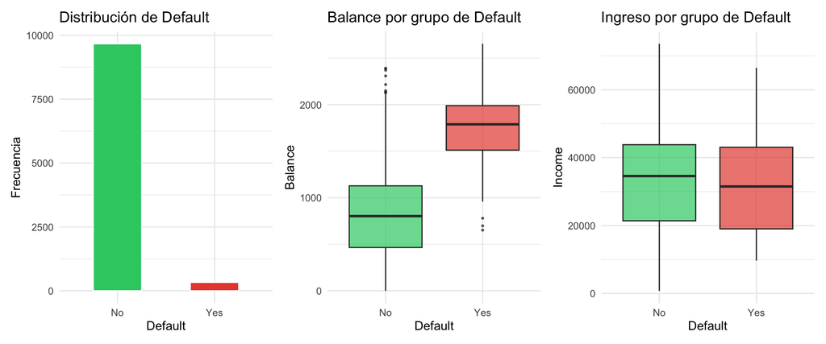

```r
# Distribución de default
p1 <- ggplot(Default, aes(x = default, fill = default)) +
  geom_bar(width = 0.5, color = "white") +
  scale_fill_manual(values = c("#2ecc71", "#e74c3c")) +
  labs(title = "Distribución de Default", x = "Default", y = "Frecuencia") +
  theme_minimal(base_size = 13) +
  theme(legend.position = "none")

# Balance por grupo
p2 <- ggplot(Default, aes(x = default, y = balance, fill = default)) +
  geom_boxplot(alpha = 0.7, outlier.size = 0.8) +
  scale_fill_manual(values = c("#2ecc71", "#e74c3c")) +
  labs(title = "Balance por grupo de Default", x = "Default", y = "Balance") +
  theme_minimal(base_size = 13) +
  theme(legend.position = "none")

# Income por grupo
p3 <- ggplot(Default, aes(x = default, y = income, fill = default)) +
  geom_boxplot(alpha = 0.7, outlier.size = 0.8) +
  scale_fill_manual(values = c("#2ecc71", "#e74c3c")) +
  labs(title = "Ingreso por grupo de Default", x = "Default", y = "Income") +
  theme_minimal(base_size = 13) +
  theme(legend.position = "none")

p1 | p2 | p3
```

```r
# Proporción de default por condición de estudiante
Default %>%
  group_by(student, default) %>%
  summarise(n = n(), .groups = "drop") %>%
  group_by(student) %>%
  mutate(Porcentaje = round(n / sum(n) * 100, 2)) %>%
  kable(
    col.names = c("Estudiante", "Default", "Frecuencia", "Porcentaje (%)"),
    caption   = "Tabla 2. Default según condición de estudiante"
  ) %>%
  kable_styling(bootstrap_options = c("striped", "hover"), full_width = FALSE)
```

Tabla 2. Default según condición de estudiante

| Estudiante | Default | Frecuencia | Porcentaje (%) |
| --- | --- | --- | --- |
| No | No | 6850 | 97.08 |
| No | Yes | 206 | 2.92 |
| Yes | No | 2817 | 95.69 |
| Yes | Yes | 127 | 4.31 |

**Observaciones clave:**

- Solo el **3.33%** de los clientes incumplió el pago → clases desbalanceadas.
- Los clientes en default tienen **balances promedio significativamente mayores**.
- El ingreso muestra menor diferencia entre grupos.

# 2. Separación en Entrenamiento y Prueba

```r
# Convertir default a factor binario 0/1
Default <- Default %>%
  mutate(default_bin = ifelse(default == "Yes", 1, 0))

n      <- nrow(Default)
idx    <- sample(1:n, size = floor(0.7 * n))

train  <- Default[idx, ]
test   <- Default[-idx, ]

cat("Tamaño del conjunto de entrenamiento:", nrow(train), "\n")
```

```
## Tamaño del conjunto de entrenamiento: 7000
```

```r
cat("Tamaño del conjunto de prueba:       ", nrow(test),  "\n")
```

```
## Tamaño del conjunto de prueba:        3000
```

```r
cat("\nProporción de default en entrenamiento:",
    round(mean(train$default == "Yes") * 100, 2), "%\n")
```

```
##
## Proporción de default en entrenamiento: 3.39 %
```

```r
cat("Proporción de default en prueba:      ",
    round(mean(test$default  == "Yes") * 100, 2), "%\n")
```

```
## Proporción de default en prueba:       3.2 %
```

Se usó una partición **70% entrenamiento / 30% prueba** con semilla `set.seed(42)` para reproducibilidad.

# 3. Regresión Logística Binaria

## Ajuste del modelo

```r
modelo_log <- glm(
  default_bin ~ student + balance + income,
  data   = train,
  family = binomial(link = "logit")
)

summary(modelo_log)
```

```
##
## Call:
## glm(formula = default_bin ~ student + balance + income, family = binomial(link = "logit"),
##     data = train)
##
## Coefficients:
##               Estimate Std. Error z value Pr(>|z|)
## (Intercept) -1.077e+01  5.780e-01 -18.640   <2e-16 ***
## studentYes  -5.621e-01  2.739e-01  -2.053   0.0401 *
## balance      5.728e-03  2.751e-04  20.818   <2e-16 ***
## income      -1.538e-07  9.591e-06  -0.016   0.9872
## ---
## Signif. codes:  0 '***' 0.001 '**' 0.01 '*' 0.05 '.' 0.1 ' ' 1
##
## (Dispersion parameter for binomial family taken to be 1)
##
##     Null deviance: 2070.7  on 6999  degrees of freedom
## Residual deviance: 1116.8  on 6996  degrees of freedom
## AIC: 1124.8
##
## Number of Fisher Scoring iterations: 8
```

## Interpretación de coeficientes

```r
# Odds Ratios con intervalos de confianza
or_table <- exp(cbind(OR = coef(modelo_log), confint(modelo_log)))

or_table %>%
  as.data.frame() %>%
  rownames_to_column("Variable") %>%
  mutate(across(where(is.numeric), ~ round(.x, 4))) %>%
  kable(
    col.names = c("Variable", "Odds Ratio", "IC 2.5%", "IC 97.5%"),
    caption   = "Tabla 3. Odds Ratios — Regresión Logística"
  ) %>%
  kable_styling(bootstrap_options = c("striped", "hover"), full_width = FALSE)
```

Tabla 3. Odds Ratios — Regresión Logística

| Variable | Odds Ratio | IC 2.5% | IC 97.5% |
| --- | --- | --- | --- |
| (Intercept) | 0.0000 | 0.0000 | 0.0001 |
| studentYes | 0.5700 | 0.3338 | 0.9777 |
| balance | 1.0057 | 1.0052 | 1.0063 |
| income | 1.0000 | 1.0000 | 1.0000 |

## Predicciones y matriz de confusión

```r
# Probabilidades predichas
prob_log <- predict(modelo_log, newdata = test, type = "response")

# Clasificación con umbral 0.5
pred_log <- ifelse(prob_log >= 0.5, "Yes", "No") %>%
  factor(levels = c("No", "Yes"))

# Matriz de confusión
cm_log <- confusionMatrix(pred_log, test$default,
                           positive = "Yes")
cm_log
```

```
## Confusion Matrix and Statistics
##
##           Reference
## Prediction   No  Yes
##        No  2892   63
##        Yes   12   33
##
##                Accuracy : 0.975
##                  95% CI : (0.9688, 0.9803)
##     No Information Rate : 0.968
##     P-Value [Acc > NIR] : 0.01425
##
##                   Kappa : 0.457
##
##  Mcnemar's Test P-Value : 7.764e-09
##
##             Sensitivity : 0.3438
##             Specificity : 0.9959
##          Pos Pred Value : 0.7333
##          Neg Pred Value : 0.9787
##              Prevalence : 0.0320
##          Detection Rate : 0.0110
##    Detection Prevalence : 0.0150
##       Balanced Accuracy : 0.6698
##
##        'Positive' Class : Yes
##
```

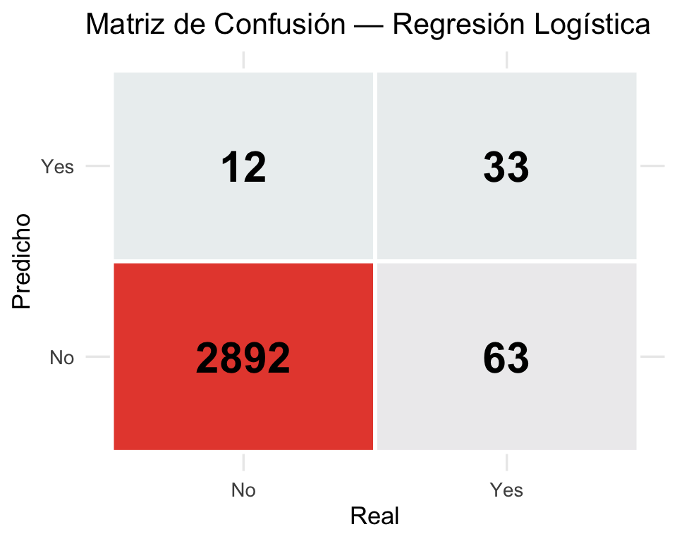

```r
# Visualización de la matriz de confusión
cm_log_df <- as.data.frame(cm_log$table)

ggplot(cm_log_df, aes(x = Reference, y = Prediction, fill = Freq)) +
  geom_tile(color = "white", linewidth = 1) +
  geom_text(aes(label = Freq), size = 8, fontface = "bold") +
  scale_fill_gradient(low = "#ecf0f1", high = "#e74c3c") +
  labs(title = "Matriz de Confusión — Regresión Logística",
       x = "Real", y = "Predicho") +
  theme_minimal(base_size = 13) +
  theme(legend.position = "none")
```

# 4. Análisis Discriminante Lineal (LDA)

## Ajuste del modelo

```r
modelo_lda <- lda(
  default ~ student + balance + income,
  data = train
)

modelo_lda
```

```
## Call:
## lda(default ~ student + balance + income, data = train)
##
## Prior probabilities of groups:
##         No        Yes
## 0.96614286 0.03385714
##
## Group means:
##     studentYes   balance   income
## No   0.2898122  805.2095 33500.25
## Yes  0.3966245 1746.1573 31611.72
##
## Coefficients of linear discriminants:
##                      LD1
## studentYes -1.496214e-01
## balance     2.240429e-03
## income      3.013408e-06
```

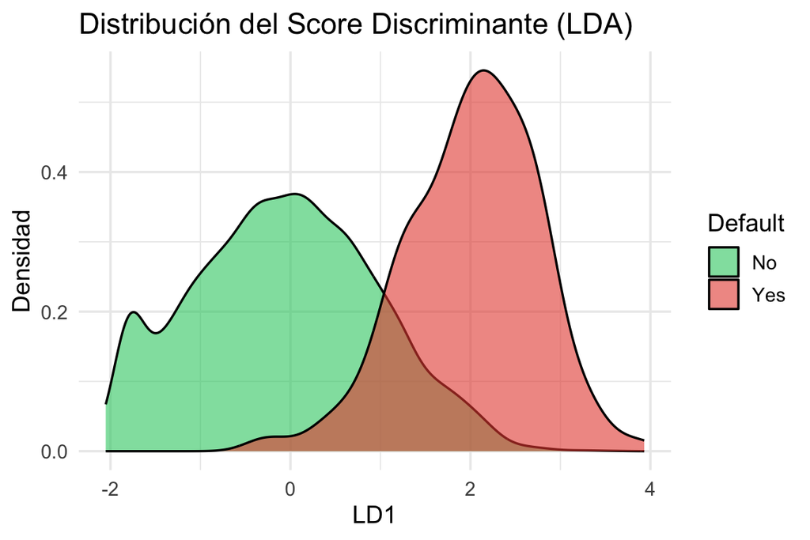

```r
# Scores discriminantes en entrenamiento
lda_values <- predict(modelo_lda, train)

lda_scores <- data.frame(
  LD1     = lda_values$x[, 1],
  default = train$default
)

ggplot(lda_scores, aes(x = LD1, fill = default)) +
  geom_density(alpha = 0.6) +
  scale_fill_manual(values = c("#2ecc71", "#e74c3c")) +
  labs(title = "Distribución del Score Discriminante (LDA)",
       x = "LD1", y = "Densidad", fill = "Default") +
  theme_minimal(base_size = 13)
```

## Predicciones y matriz de confusión

```r
pred_lda_obj <- predict(modelo_lda, newdata = test)
pred_lda     <- pred_lda_obj$class

cm_lda <- confusionMatrix(pred_lda, test$default,
                           positive = "Yes")
cm_lda
```

```
## Confusion Matrix and Statistics
##
##           Reference
## Prediction   No  Yes
##        No  2900   70
##        Yes    4   26
##
##                Accuracy : 0.9753
##                  95% CI : (0.9691, 0.9806)
##     No Information Rate : 0.968
##     P-Value [Acc > NIR] : 0.01065
##
##                   Kappa : 0.4036
##
##  Mcnemar's Test P-Value : 4.153e-14
##
##             Sensitivity : 0.270833
##             Specificity : 0.998623
##          Pos Pred Value : 0.866667
##          Neg Pred Value : 0.976431
##              Prevalence : 0.032000
##          Detection Rate : 0.008667
##    Detection Prevalence : 0.010000
##       Balanced Accuracy : 0.634728
##
##        'Positive' Class : Yes
##
```

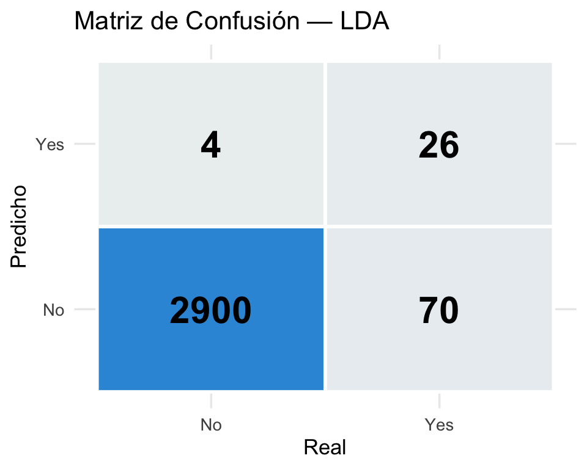

```r
cm_lda_df <- as.data.frame(cm_lda$table)

ggplot(cm_lda_df, aes(x = Reference, y = Prediction, fill = Freq)) +
  geom_tile(color = "white", linewidth = 1) +
  geom_text(aes(label = Freq), size = 8, fontface = "bold") +
  scale_fill_gradient(low = "#ecf0f1", high = "#3498db") +
  labs(title = "Matriz de Confusión — LDA",
       x = "Real", y = "Predicho") +
  theme_minimal(base_size = 13) +
  theme(legend.position = "none")
```

# 5. Comparación de Modelos

```r
# Extraer métricas de cada modelo
extraer_metricas <- function(cm, nombre) {
  data.frame(
    Modelo         = nombre,
    Accuracy       = round(cm$overall["Accuracy"]        * 100, 2),
    Sensibilidad   = round(cm$byClass["Sensitivity"]     * 100, 2),
    Especificidad  = round(cm$byClass["Specificity"]     * 100, 2)
  )
}

tabla_comp <- bind_rows(
  extraer_metricas(cm_log, "Regresión Logística"),
  extraer_metricas(cm_lda, "LDA")
)

tabla_comp %>%
  kable(
    col.names = c("Modelo", "Accuracy (%)", "Sensibilidad (%)", "Especificidad (%)"),
    caption   = "Tabla 4. Comparación de métricas entre modelos",
    row.names = FALSE
  ) %>%
  kable_styling(bootstrap_options = c("striped", "hover", "bordered"),
                full_width = FALSE) %>%
  row_spec(which.max(tabla_comp$Sensibilidad), background = "#ffeaa7",
           bold = TRUE)
```

Tabla 4. Comparación de métricas entre modelos

| Modelo | Accuracy (%) | Sensibilidad (%) | Especificidad (%) |
| --- | --- | --- | --- |
| Regresión Logística | 97.50 | 34.38 | 99.59 |
| LDA | 97.53 | 27.08 | 99.86 |

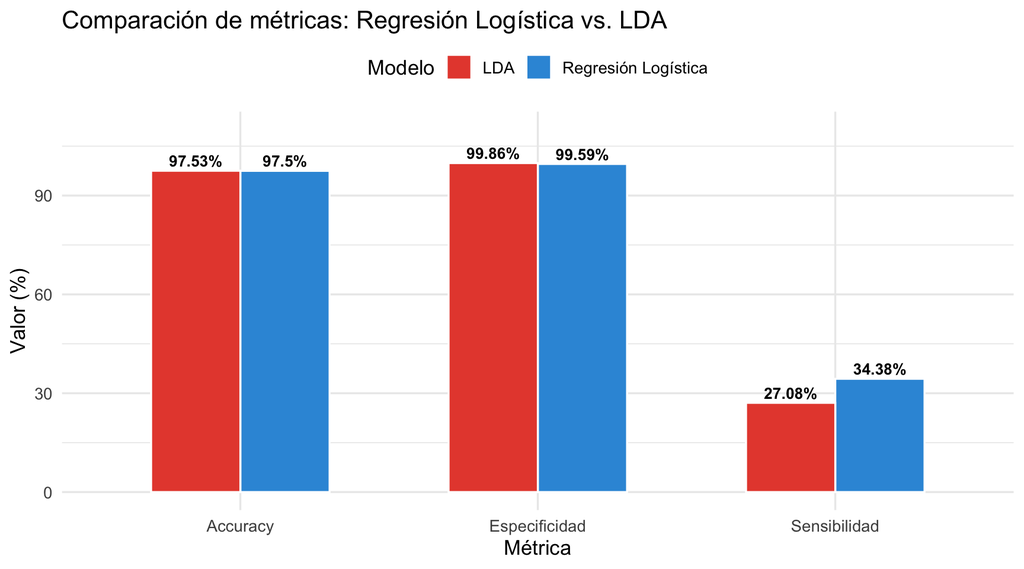

```r
# Gráfica comparativa de métricas
tabla_long <- tabla_comp %>%
  select(Modelo, Accuracy, Sensibilidad, Especificidad) %>%
  pivot_longer(-Modelo, names_to = "Métrica", values_to = "Valor")

ggplot(tabla_long, aes(x = Métrica, y = Valor, fill = Modelo)) +
  geom_bar(stat = "identity", position = "dodge", width = 0.6,
           color = "white") +
  scale_fill_manual(values = c("#e74c3c", "#3498db")) +
  geom_text(aes(label = paste0(Valor, "%")),
            position = position_dodge(width = 0.6),
            vjust = -0.4, size = 3.5, fontface = "bold") +
  ylim(0, 110) +
  labs(title  = "Comparación de métricas: Regresión Logística vs. LDA",
       x      = "Métrica",
       y      = "Valor (%)",
       fill   = "Modelo") +
  theme_minimal(base_size = 13) +
  theme(legend.position = "top")
```

# Conclusiones

| Dimensión | Resultado |
| --- | --- |
| **Accuracy** | LDA (97.53%) |
| **Sensibilidad (detectar defaults)** | Regresión Logística (34.38%) |
| **Especificidad (evitar falsas alarmas)** | LDA (99.86%) |

**Interpretación:**

1. **Sensibilidad es la métrica más crítica** en riesgo crediticio: un falso negativo (no detectar un cliente que *sí* incumplirá) tiene mayor costo financiero que un falso positivo.
2. Ambos modelos muestran alta exactitud global, pero esto se debe al **desbalance de clases** (~97% No default). La sensibilidad es el indicador más discriminante entre modelos.
3. **Regresión Logística** obtiene mejor capacidad para detectar defaults reales, por lo que sería el modelo preferido en este contexto de riesgo crediticio.
4. LDA asume normalidad multivariante y covarianzas iguales entre grupos; la Regresión Logística es más flexible y menos restrictiva en sus supuestos, lo que puede explicar diferencias en sensibilidad.

*Actividad elaborada con la base `Default` del paquete `ISLR2`.*